# cSAR geometry EBBA1 (Forest/Agriculture/Other)

Read data and libraries

```r
library(readxl)
library(sf)
library(terra)
library(dplyr)
library(purrr)

data = read.csv("own datasets/ebba1_matrix_centroids.csv", check.names = FALSE)
```

Generate and plot points and minimum convex polygon

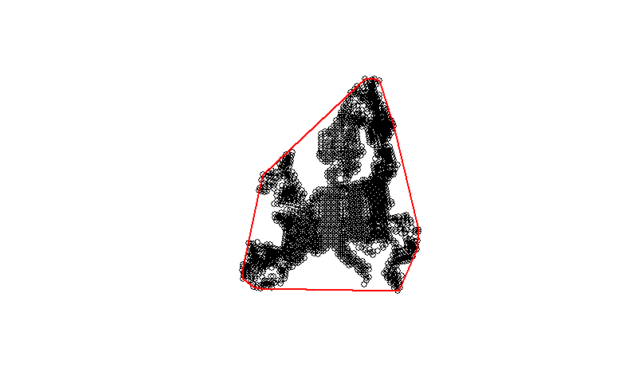

```r
points = st_as_sf(data,coords=c("lon","lat"), crs=3035)
plot(st_geometry(points))

convex_hull <- st_convex_hull(st_union(points))
plot(convex_hull, border = "red", lwd = 2, add = TRUE)
```

```r
st_coordinates(convex_hull)[1,]
```

```
      X       Y      L1      L2
5437972 1567686       1       1
```

```r
points[1,]
```

[output not shown]

[output cut: 70 more lines]

[output not shown]

**filter_points_in_expanding_circles** = A function that picks a random point and starts sampling increasing circles from those points, returning the points inside those circles.

```r
filter_points_in_expanding_circles <- function(points_sf, radius_vector, convex_hull) {
  # Randomly select one point from points_sf
  selected_point <- points_sf[sample(1:nrow(points_sf), 1), ]

  # Initialize a list to store points within each circle
  points_within_circles <- list()

  # Loop through the radius_vector
  for (radius in radius_vector) {
    # Create a buffer (circle) around the selected point with the current radius
    circle <- st_geometry(st_buffer(selected_point, dist = radius))

    # Calculate the intersection of the circle with the convex_hull
    intersection <- st_intersection(circle, convex_hull)

    # Check the area of the intersection compared to the area of the circle
    circle_area <- as.numeric(st_area(circle)) #as.numeric to remove units

    intersection_area <- as.numeric(st_area(intersection)) #as.numeric to remove units

    # Stop if the majority of the circle is outside the convex_hull
    if (intersection_area / circle_area < 0.5) {
      break
    }

    # Find points_sf that intersect the current circle
    points_in_circle <- points_sf[st_intersects(points_sf, circle, sparse = FALSE), ]

    # Add the points to the list
    points_within_circles[[paste0("radius_", radius)]] <-
      list(points=points_in_circle,circle=circle)
  }

  # Return the list of points within circles
  return(points_within_circles)
}
```

Testing the function

```r
pt_in_circles = filter_points_in_expanding_circles(points,60000*1:10,convex_hull)

plot(st_geometry(points))
plot(convex_hull, border = "red", lwd = 2, add=TRUE)
```

[output not shown]

[output cut: 1844 more lines]

[output not shown]

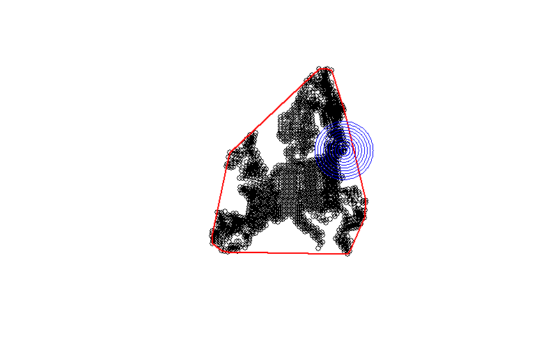

```r
for (i in seq_along(pt_in_circles))
  {
  print(pt_in_circles[[i]]$points)
  plot(st_geometry(pt_in_circles[[i]]$circle),  border = "blue", add=TRUE)
}
```

**summarize_samples** = A function that takes a list of groups of sites as a sample feature collections which has a dataframe with the species occurences, the polygons corresponding to the geometric delimitation of the groups of sites, a raster of habitat types, a vector of habitat names, the list of species in each group (each group is a list of numerical values of the columns corresponding to the species in the dataframe from the sample fature), and a vector with the species group names. The first column in the sample feature collection should be the name of the individual sample site. It produces a table with the area of each habitat and the number of species in each group and the total number of species.

```r
#habitat names should be a df with a col with habitat codes and respective habitat names
summarize_samples<- function(samples, polygons, habitat_raster, habitat_names,
                             habitat_values, species_groups, species_group_names)
  {
    # Initialize an empty data frame for the results
    results_df <- data.frame(matrix(ncol = length(habitat_names)+
                                      length(species_group_names)+2,
                                    nrow = 0))
    colnames(results_df) <- c(habitat_names,"Area_Total",species_group_names,"Sp_Total")

    # Iterate over each area sample (i.e. group of sites)
    for (i in seq_along(samples)) {
      sample <- samples[[i]]
      polygon <- polygons[[i]]

      # Crop and mask the raster to the polygon extent
      habitat_cropped <- crop(habitat_raster, vect(polygon))
      habitat_masked <- mask(habitat_cropped, vect(polygon))

      # Calculate the area of each habitat type
      habitat_df <- freq(habitat_masked, bylayer=FALSE)
      habitat_df <- rbind(habitat_df,freq(habitat_masked, bylayer=FALSE,value=NA))

      # Ensure all possible values are included
      all_values_df <- data.frame(value = habitat_values, count = 0)

      # Merge with actual frequency data, replacing 0 where missing
      habitat_df <- merge(all_values_df, habitat_df, by = "value", all.x = TRUE)

       # Fill NA counts with 0
      habitat_df$count <- ifelse(is.na(habitat_df$count.y), 0, habitat_df$count.y)

      # Drop unnecessary column
      habitat_df <- habitat_df[, c("value", "count")]

      habitat_df$area <- habitat_df$count * res(habitat_raster)[1] * res(habitat_raster)[2]

      # Store the results
      results_df[i, seq_along(habitat_names)] <- habitat_df$area # store area of each habitat
      results_df[i, length(habitat_names)+1] <-
        sum(results_df[i, seq_along(habitat_names)]) # store total area

      # Subset species occurrences for each group
      total_species=0
      for (k in seq_along(species_groups))
      {
        group_species <- st_drop_geometry(sample)[, species_groups[[k]]+1 ]
        species_present <- colSums(group_species > 0)  # Count species occurrences
        num_species <- sum(species_present > 0)       # Number of species in the group
        results_df[i, length(habitat_names)+1+k] <- num_species #store species number in results
        total_species <- total_species + num_species
      }

      #store the total number of species by summing across species groups
      results_df[i, length(habitat_names)+length(species_groups)+2] = total_species
    }

    return(results_df)
  }
```

Try the function

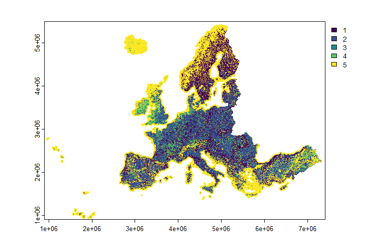

```r
lu2000 <- rast("own datasets/simplified_land_use_2000.tif")
plot(lu2000)
```

```r
habitat_names <- c("Forest", "Agriculture", "Urban", "Grasslands", "Other")
habitat_values <- c(1,2,3,4,5)
species_group_names = c("Sp_Forest", "Sp_Generalist")
species_groups = list(c(1,2,3),c(6,7,8))
  samples=lapply(pt_in_circles, \(x) x$points)
polygons=lapply(pt_in_circles, \(x) x$circle)
res=summarize_samples(samples, polygons,
                lu2000, habitat_names, habitat_values,
                species_groups, species_group_names)
```

```
|---------|---------|---------|---------|
=========================================


|---------|---------|---------|---------|
=========================================


|---------|---------|---------|---------|
=========================================


|---------|---------|---------|---------|
=========================================


|---------|---------|---------|---------|
=========================================


|---------|---------|---------|---------|
=========================================
```

```r
head(res)
```

|  | Forest | Agriculture | Urban | Grasslands | Other | Area_Total | Sp_Forest | Sp_Generalist | Sp_Total |
| --- | --- | --- | --- | --- | --- | --- | --- | --- | --- |
| 1 | 2050830000 | 1833650000 | 73890000 | 411890000 | 591840000 | 4962100000 | 2 | 0 | 2 |
| 2 | 7280710000 | 10083560000 | 504790000 | 2291810000 | 2034790000 | 22195660000 | 2 | 0 | 2 |
| 3 | 16709580000 | 22461550000 | 1128340000 | 5942000000 | 4895230000 | 51136700000 | 2 | 0 | 2 |
| 4 | 28959900000 | 37935980000 | 1840180000 | 8942000000 | 7783320000 | 85461380000 | 2 | 1 | 3 |
| 5 | 41909290000 | 53605160000 | 2556760000 | 11957660000 | 13382430000 | 123411300000 | 3 | 2 | 5 |
| 6 | 56839550000 | 69734860000 | 3265260000 | 16295900000 | 24459220000 | 170594790000 | 3 | 2 | 5 |

Now with the real species classification

```r
classif<-read.csv("own datasets/aves_classification_fag.csv")
classif$forest_sp==1
```

```
  [1]  TRUE  TRUE  TRUE FALSE FALSE FALSE FALSE FALSE  TRUE FALSE FALSE  TRUE FALSE FALSE FALSE FALSE FALSE  TRUE  TRUE FALSE FALSE  TRUE
 [23]  TRUE FALSE FALSE FALSE  TRUE FALSE FALSE FALSE  TRUE FALSE FALSE FALSE FALSE FALSE  TRUE FALSE FALSE FALSE FALSE FALSE FALSE FALSE
 [45] FALSE FALSE FALSE FALSE FALSE FALSE FALSE FALSE  TRUE FALSE FALSE FALSE FALSE FALSE FALSE  TRUE FALSE  TRUE  TRUE FALSE FALSE FALSE
 [67] FALSE FALSE FALSE FALSE  TRUE FALSE FALSE  TRUE FALSE  TRUE FALSE FALSE FALSE FALSE FALSE FALSE  TRUE FALSE FALSE FALSE FALSE FALSE
 [89] FALSE FALSE FALSE  TRUE FALSE FALSE FALSE FALSE FALSE FALSE FALSE FALSE FALSE FALSE  TRUE FALSE FALSE FALSE FALSE  TRUE FALSE FALSE
[111] FALSE FALSE FALSE FALSE FALSE FALSE FALSE FALSE FALSE FALSE FALSE FALSE FALSE  TRUE FALSE FALSE  TRUE FALSE  TRUE FALSE FALSE FALSE
[133] FALSE FALSE FALSE FALSE  TRUE FALSE  TRUE FALSE  TRUE FALSE FALSE FALSE FALSE FALSE FALSE FALSE FALSE  TRUE  TRUE FALSE FALSE FALSE
[155]  TRUE FALSE FALSE FALSE FALSE FALSE FALSE FALSE  TRUE FALSE  TRUE  TRUE  TRUE FALSE FALSE FALSE FALSE FALSE  TRUE FALSE FALSE FALSE
[177] FALSE FALSE  TRUE FALSE FALSE FALSE FALSE FALSE FALSE  TRUE  TRUE FALSE FALSE  TRUE FALSE  TRUE FALSE FALSE FALSE FALSE  TRUE FALSE
[199] FALSE FALSE  TRUE FALSE FALSE FALSE  TRUE FALSE  TRUE  TRUE FALSE FALSE  TRUE  TRUE  TRUE FALSE  TRUE FALSE  TRUE  TRUE FALSE FALSE
[221]  TRUE FALSE FALSE FALSE FALSE  TRUE  TRUE FALSE FALSE FALSE FALSE FALSE FALSE FALSE FALSE FALSE  TRUE FALSE FALSE FALSE FALSE  TRUE
[243]  TRUE FALSE FALSE FALSE FALSE  TRUE FALSE FALSE FALSE FALSE FALSE FALSE FALSE  TRUE FALSE FALSE FALSE FALSE FALSE FALSE FALSE FALSE
[265] FALSE FALSE FALSE FALSE FALSE FALSE  TRUE FALSE FALSE FALSE FALSE  TRUE FALSE FALSE FALSE  TRUE  TRUE FALSE  TRUE FALSE FALSE FALSE
[287] FALSE  TRUE FALSE FALSE FALSE FALSE  TRUE  TRUE FALSE FALSE FALSE FALSE FALSE FALSE FALSE FALSE FALSE FALSE FALSE FALSE FALSE FALSE
[309]  TRUE FALSE FALSE FALSE  TRUE FALSE FALSE FALSE FALSE FALSE FALSE FALSE FALSE FALSE FALSE FALSE FALSE FALSE FALSE FALSE  TRUE  TRUE
```

[output cut: 16 more lines]

```r
forest=classif[classif$forest_sp==1,]$species
posfor=match(forest,colnames(data))-3
res=summarize_samples(samples, polygons,
                lu2000, habitat_names, habitat_values,
                list(na.omit(posfor)), list("Sp_Forest"))
```

```
|---------|---------|---------|---------|
=========================================


|---------|---------|---------|---------|
=========================================


|---------|---------|---------|---------|
=========================================


|---------|---------|---------|---------|
=========================================


|---------|---------|---------|---------|
=========================================


|---------|---------|---------|---------|
=========================================
```

```r
res
```

|  | Forest | Agriculture | Urban | Grasslands | Other | Area_Total | Sp_Forest | Sp_Total |
| --- | --- | --- | --- | --- | --- | --- | --- | --- |
| 1 | 2050830000 | 1833650000 | 73890000 | 411890000 | 591840000 | 4962100000 | 51 | 51 |
| 2 | 7280710000 | 10083560000 | 504790000 | 2291810000 | 2034790000 | 22195660000 | 53 | 53 |
| 3 | 16709580000 | 22461550000 | 1128340000 | 5942000000 | 4895230000 | 51136700000 | 55 | 55 |
| 4 | 28959900000 | 37935980000 | 1840180000 | 8942000000 | 7783320000 | 85461380000 | 56 | 56 |
| 5 | 41909290000 | 53605160000 | 2556760000 | 11957660000 | 13382430000 | 123411300000 | 58 | 58 |
| 6 | 56839550000 | 69734860000 | 3265260000 | 16295900000 | 24459220000 | 170594790000 | 59 | 59 |
| 7 | 70547530000 | 83345420000 | 3783250000 | 20198190000 | 43112970000 | 220987360000 | 60 | 60 |
| 8 | 86354070000 | 101509040000 | 4698430000 | 24321660000 | 54870050000 | 271753250000 | 60 | 60 |
| 9 | 93636580000 | 122487800000 | 6399410000 | 27339550000 | 78617560000 | 328480900000 | 60 | 60 |
| 10 | 113151510000 | 150077950000 | 8550450000 | 30175860000 | 103184850000 | 405140620000 | 62 | 62 |

**create_squares** = Create an sf where each sampling point is associated with a sampling square centred in the point and with a width dx.

```r
create_squares <- function(points_sf, width) {
  # Ensure the input is a point sf object
  if (!inherits(points_sf, "sf") || !inherits(st_geometry(points_sf), "sfc_POINT")) {
    stop("Input must be an sf object with point geometries.")
  }
  # Calculate half-width (to shift the square corners)
  half_width <- width / 2

  squares_sf <- st_as_sf(st_buffer(points_sf, dist = half_width, endCapStyle = "SQUARE"))

  return(squares_sf)
}
```

Try function

```r
class(points)
```

```
[1] "sf"         "data.frame"
```

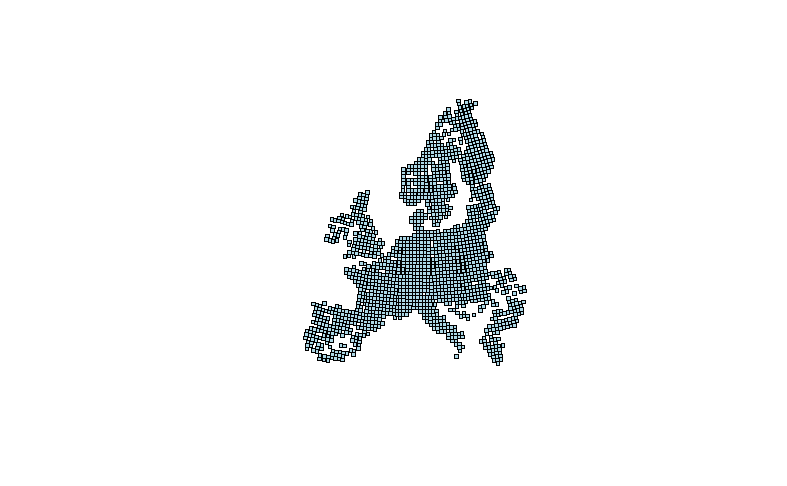

```r
squares_sf <- create_squares(points, width = 50000)

# Plot points and squares
plot(st_geometry(squares_sf), col = "lightblue", border = "black")  # Squares
```

**filter_points_in_clusters** = Filter points for type II/III SAR (fractals sampling scheme or sub-divisions), Points should have an associated sampling square as geometry feature instead of a point geometry.

```r
filter_points_in_clusters <- function(points_sf, squares_sf, cluster_size_vector)
  {
    npoints = nrow(points_sf)
    n_clusters_vector = npoints%/%cluster_size_vector
    n_clusters_vector[n_clusters_vector==0]=1  # when whole landscape, npoints<cluster_size
    points_within_clusters<- list()
    for (n_clusters in n_clusters_vector)
    {
      if(n_clusters==npoints)
      {
        points_in_clusters <- split(points_sf, 1:npoints)
        clusters_convex_hulls <- split(st_geometry(squares_sf), 1:npoints)
      }
      else
      {
      # Extract coordinates for k-means
      coords <- st_coordinates(points_sf)

      # Perform k-means clustering
      kmeans_result <- kmeans(coords, centers = n_clusters)

      # split the points sf into a list of clusters of points
      points_in_clusters <- split(points_sf,kmeans_result$cluster)
      squares_in_clusters <- split(squares_sf,kmeans_result$cluster)

      # Merge all squares into a single geometry
      merged_geom_within_clusters <- lapply(squares_in_clusters, st_union)

      # Compute convex hull
      clusters_convex_hulls <- lapply(merged_geom_within_clusters, st_convex_hull)

      #clusters_convex_hulls <- lapply(points_in_clusters,
      #                                   function(points) {st_convex_hull(st_union(points))})
      }
      # Add the points to the list
      points_within_clusters[[paste0("size_",
                                     cluster_size_vector[n_clusters_vector==n_clusters]) ]] <-
        list(points=points_in_clusters,chulls=clusters_convex_hulls)
    }
  # Return the list of points within clusters
  return(points_within_clusters)
}
```

Try function

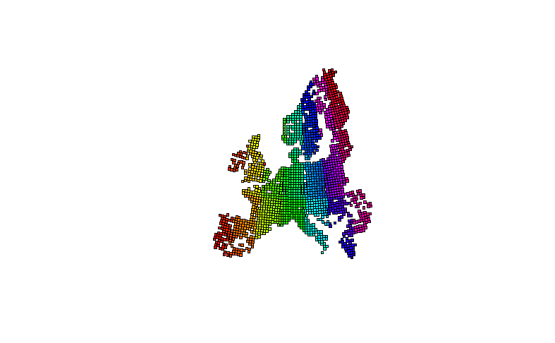

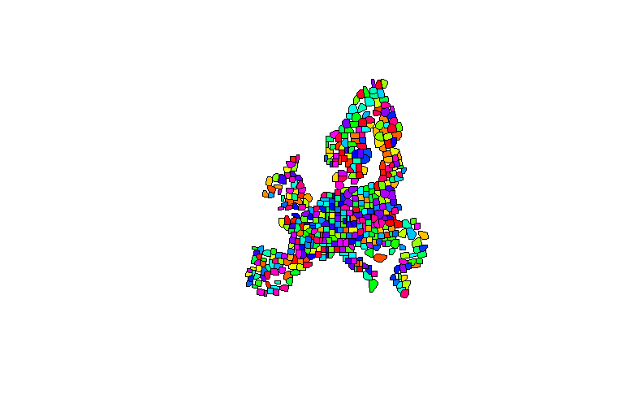

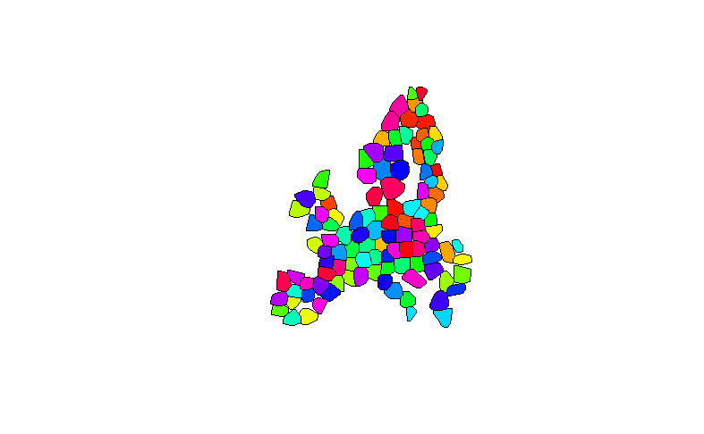

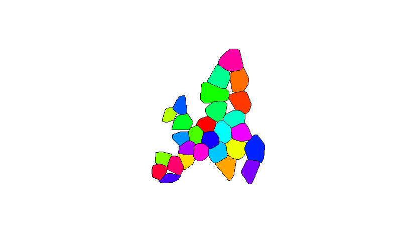

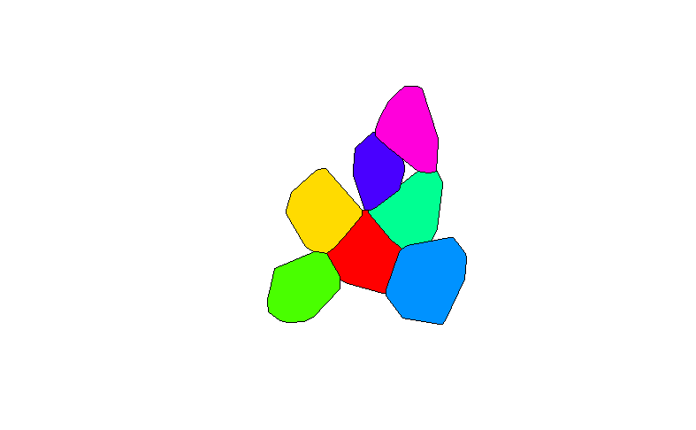

```r
squares_sf <- create_squares(points, width = 50000) # changed to 50,000 to fit minimum size of EBBA grid cells
pt_in_clusters = filter_points_in_clusters(points,squares_sf,c(1,4,16,64,256,1024))

clusters_chulls = lapply(pt_in_clusters , \(x) x$chulls)

for (size in seq_along(clusters_chulls))
{
  # Set up colors
colors <- rainbow(length(clusters_chulls[[size]]))
plot(st_geometry(points), col = rgb(0, 1, 0, 0))
# Add remaining polygons with different colors
  for (i in 1:length(clusters_chulls[[size]])) {
    plot(clusters_chulls[[size]][[i]], col = colors[i], border = "black", add = TRUE)
  }
}
```

[figure not shown]

```r
NA
```

##sumarize the samples for SAR type III

```r
extract_species_positions <- function(species_habitat_matrix, species_site_matrix) {
  # Get habitat names
  habitat_names <- colnames(species_habitat_matrix[,-1])

  # Initialize a list to store species positions for each habitat
  habitat_positions <- list()

  # Loop through each habitat
  for (habitat in habitat_names) {
    # Get species associated with this habitat
    species_in_habitat <-
      rownames(species_habitat_matrix)[species_habitat_matrix[, habitat] == 1]

    # Find positions (indices) of these species in the species-site matrix
    species_positions <- which(rownames(species_site_matrix) %in% species_in_habitat)

    # Store results in the list
    habitat_positions[[habitat]] <- species_positions
  }

  return(habitat_positions)
}
```

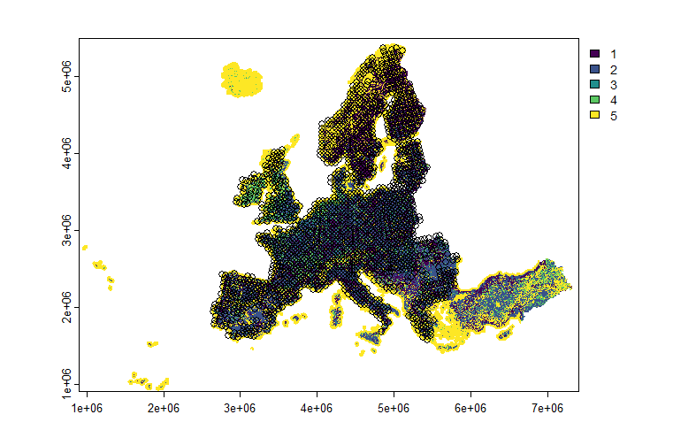

```r
lu2000 <- rast("own datasets/simplified_land_use_2000.tif")
plot(lu2000)
plot(st_geometry(points),add=TRUE)
```

```r
squares_sf <- create_squares(points, width = 50000) # changed to 50,000 to fit minimum size of EBBA grid cells
pt_in_clusters = filter_points_in_clusters(points,squares_sf,c(1,4,16,64,256,1024))
habitat_names <- c("Forest", "Agriculture", "Urban", "Grassland", "Other")
habitat_values <- c(1,2,3,4,5)
species_group_names = c("forest_sp", "agriculture_sp", "generalist_sp")

classif<-read.csv("own datasets/aves_classification_EBBA1_fag.csv")
species_groups = extract_species_positions(classif,points[,-1])

samples=lapply(pt_in_clusters , \(x) x$points)
polygons=lapply(pt_in_clusters , \(x) x$chulls)
res=summarize_samples(flatten(samples), flatten(polygons),
                lu2000, habitat_names, habitat_values, species_groups,
                names(species_groups))
```

[output not shown]

[output cut: 51 more lines]

[output not shown]

```r
res
```

|  | Forest | Agriculture | Urban | Grassland | Other | Area_Total | forest_sp | agriculture_sp | generalist_sp | Sp_Total |
| --- | --- | --- | --- | --- | --- | --- | --- | --- | --- | --- |
| 1 | 147070000 | 292150000 | 454400000 | 20770000 | 1575750000 | 2490140000 | 29 | 22 | 60 | 111 |
| 2 | 172980000 | 395020000 | 49980000 | 810000 | 1579250000 | 2198040000 | 24 | 23 | 58 | 105 |
| 3 | 175890000 | 1257450000 | 148490000 | 14550000 | 903620000 | 2500000000 | 31 | 28 | 61 | 120 |
| 4 | 619460000 | 781250000 | 9630000 | 45460000 | 1044200000 | 2500000000 | 29 | 23 | 52 | 104 |
| 5 | 565210000 | 517030000 | 59010000 | 50480000 | 1308270000 | 2500000000 | 33 | 29 | 61 | 123 |
| 6 | 248050000 | 1979790000 | 12970000 | 16870000 | 242320000 | 2500000000 | 30 | 21 | 57 | 108 |
| 7 | 991010000 | 445190000 | 30880000 | 380000 | 1032540000 | 2500000000 | 27 | 22 | 62 | 111 |
| 8 | 597140000 | 1807380000 | 24770000 | 3650000 | 67060000 | 2500000000 | 30 | 25 | 62 | 117 |
| 9 | 469440000 | 1897980000 | 24410000 | 13200000 | 94970000 | 2500000000 | 30 | 21 | 64 | 115 |
| 10 | 597850000 | 1300620000 | 132000000 | 30240000 | 439290000 | 2500000000 | 26 | 26 | 60 | 112 |

[output cut: 990 more lines]

# SAR analysis

```r
res = read.csv("own datasets/cSARgeom_EBBA1_FAG")
```

[output not shown]